# Vinegar Merlin Hardware Survey Report (Dec 2023)

lunarlattice

2023-12-31

# THIS IS WIP!

This file (and full data) is available as a .Rmd file at https://vinegarhq.org/VinegarSystemSurvey.Rmd

## Background

The effort to run Roblox on Linux (hereafter abbreviated RoL) has faced many complications. Considering that the platform still does not have official support, nor even binaries built for x86_64 Linux, RoL wrappers including Grapejuice and Vinegar have had to run the Windows version of Roblox under the Wine compatibility layer, often leading to issues with Hyperion. Furthermore, as a result of Hyperion’s vague messages and complexity, we are frequently unable to troubleshoot for problems on our users’ systems.

An effort to “standardize” the platform on which Roblox runs has been made via distribution of RoL wrappers via the Flatpak packaging system, which provides a stable platform, but is still not always successful.

Additionally, some users on older processors without the AVX instruction set have reported being blocked by Hyperion.

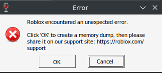

The Hyperion Error in Question

## Why Merlin?

I chose to begin the Merlin project not only to gauge the minimum size of the RoL userbase of Vinegar, but also to identify the most popular distribution methods, kernels, and processors. The issue of statistics regarding AVX was also a major topic; I wanted to see how much of our userbase was affected, and whether more research was warranted.

The data collected included:

- Vinegar Version (1.6.0 for all systems)
- Kernel
- Whether the user was using Flatpak
- The presence of AVX
- CPU Model
- GPU driver name

The survey began on December 21, 2023.

## Limitations

While Merlin was designed to collect as much pertinent information as possible, our users were not willing to provide any identifiers, and were given the opportunity to chose to not participate.

Additionally, we were not able to identify whether Roblox Player was successful at launching on the system due to a lack of bindings to the Roblox executable, but are working on a fix for a future survey.

Our GPU data collection only includes driver name, but will be improved in a future release to collect actual model names.

## Results

The results of the survey can be retrieved at https://merlin.vinegarhq.org

```r
merlin <- read.csv("https://merlin.vinegarhq.org/")
head(merlin)
```

```
##          project                                  distro
## 1 Vinegar v1.6.0                              Arch Linux
## 2 Vinegar v1.6.0 Freedesktop SDK 23.08 (Flatpak runtime)
## 3 Vinegar v1.6.0 Freedesktop SDK 23.08 (Flatpak runtime)
## 4 Vinegar v1.6.0                              Arch Linux
## 5 Vinegar v1.6.0 Freedesktop SDK 23.08 (Flatpak runtime)
## 6 Vinegar v1.6.0                              Arch Linux
##                    kernel flatpak  avx
## 1        6.6.7-zen1-1-zen   false true
## 2        6.1.68-1-MANJARO    true true
## 3   6.6.6-200.fc39.x86_64    true true
## 4 6.7.0-rc6-273-tkg-eevdf   false true
## 5        6.5.0-14-generic    true true
## 6         6.6.8-2-cachyos   false true
##                                             cpu           gpu
## 1 AMD Ryzen 5 3500U with Radeon Vega Mobile Gfx        amdgpu
## 2   AMD Ryzen 5 3400G with Radeon Vega Graphics        nvidia
## 3    AMD Ryzen 5 PRO 5650U with Radeon Graphics        amdgpu
## 4           AMD Ryzen 7 3800XT 8-Core Processor amdgpu,amdgpu
## 5            AMD Ryzen 7 5800X 8-Core Processor        amdgpu
## 6            AMD Ryzen 5 5600X 6-Core Processor        amdgpu
```

*A preview of the data.*

There are 2841 submissions at the time of writing.

### Processor Model Statistics

| cpu | n | cpu_prop | cpu_prop_as_perc |
| --- | --- | --- | --- |
| AMD Custom APU 0405 | 303 | 0.1066526 | 10.6652587 |
| AMD Ryzen 5 3600 6-Core Processor | 60 | 0.0211193 | 2.1119324 |
| 11th Gen Intel(R) Core(TM) i5-1135G7 @ 2.40GHz | 50 | 0.0175994 | 1.7599437 |
| AMD Ryzen 5 2600 Six-Core Processor | 42 | 0.0147835 | 1.4783527 |
| AMD Ryzen 5 5600G with Radeon Graphics | 42 | 0.0147835 | 1.4783527 |
| AMD Ryzen 5 5600X 6-Core Processor | 40 | 0.0140795 | 1.4079549 |
| 11th Gen Intel(R) Core(TM) i3-1115G4 @ 3.00GHz | 39 | 0.0137276 | 1.3727561 |
| AMD Ryzen 5 5600 6-Core Processor | 34 | 0.0119676 | 1.1967617 |
| Intel(R) Core(TM) i5-8250U CPU @ 1.60GHz | 28 | 0.0098557 | 0.9855685 |
| Intel(R) Core(TM) i7-10750H CPU @ 2.60GHz | 27 | 0.0095037 | 0.9503696 |
| AMD Ryzen 7 3700X 8-Core Processor | 26 | 0.0091517 | 0.9151707 |
| AMD Ryzen 5 5600H with Radeon Graphics | 25 | 0.0087997 | 0.8799718 |
| Intel(R) Core(TM) i3-1005G1 CPU @ 1.20GHz | 25 | 0.0087997 | 0.8799718 |
| Intel(R) Core(TM) i5-10400F CPU @ 2.90GHz | 24 | 0.0084477 | 0.8447730 |
| AMD Ryzen 3 3200G with Radeon Vega Graphics | 23 | 0.0080957 | 0.8095741 |
| Intel(R) Core(TM) i5-1035G1 CPU @ 1.00GHz | 23 | 0.0080957 | 0.8095741 |
| AMD Ryzen 7 5700U with Radeon Graphics | 21 | 0.0073918 | 0.7391763 |
| AMD Ryzen 7 5800X 8-Core Processor | 21 | 0.0073918 | 0.7391763 |
| Intel(R) Core(TM) i5-7200U CPU @ 2.50GHz | 21 | 0.0073918 | 0.7391763 |
| 11th Gen Intel(R) Core(TM) i5-11400H @ 2.70GHz | 20 | 0.0070398 | 0.7039775 |
| Intel(R) Core(TM) i5-8265U CPU @ 1.60GHz | 20 | 0.0070398 | 0.7039775 |
| 12th Gen Intel(R) Core(TM) i5-12400F | 19 | 0.0066878 | 0.6687786 |
| AMD Ryzen 7 5700X 8-Core Processor | 19 | 0.0066878 | 0.6687786 |
| AMD Ryzen 9 5900X 12-Core Processor | 19 | 0.0066878 | 0.6687786 |
| Intel(R) Core(TM) i5-2400 CPU @ 3.10GHz | 19 | 0.0066878 | 0.6687786 |
| AMD Ryzen 5 1600 Six-Core Processor | 18 | 0.0063358 | 0.6335797 |
| AMD Ryzen 5 3500U with Radeon Vega Mobile Gfx | 18 | 0.0063358 | 0.6335797 |
| Intel(R) Core(TM) i5-10300H CPU @ 2.50GHz | 18 | 0.0063358 | 0.6335797 |
| 11th Gen Intel(R) Core(TM) i7-1165G7 @ 2.80GHz | 17 | 0.0059838 | 0.5983809 |
| AMD Ryzen 7 5800H with Radeon Graphics | 17 | 0.0059838 | 0.5983809 |

[output cut: 501 more lines]

*cpu_prop indicates the proportion of the CPU model out of all models where a value of 1 = 100%, and cpu_prop_as_perc represents the same statistic as a percentage out of 100.*

Considering the great number Steam Deck of users, Roblox may benefit from tapping into providing the userbase with a native binary. Additionally, Roblox’s concerns over compatbility would be minimal on Steam Deck, as users not only have identical hardware, but are also only able to use Flatpak, ensuring a stable software platform.

### AVX Support

1.0911651% of the Vinegar userbase does not have AVX.

While the probability of not having AVX is unusual (0.0109117 < 0.05), it is a non-zero value. We were not able to confirm whether those with AVX are able to successfully run RoL (as mentioned in Limitations). Consequently, we have decided to automatically provide a warning to users without AVX.

Whether AVX is the actual culprit for the issue with Hyperion is called into question by the results of this survey; more research is warranted, and insight from upstream developers (including from Wine and Roblox) would be beneficial.

### GPU Statistics

| gpu | n | gpu_prop | gpu_prop_as_perc |
| --- | --- | --- | --- |
| amdgpu | 909 | 0.3199578 | 31.9957761 |
| i915 | 754 | 0.2653995 | 26.5399507 |
| nvidia | 395 | 0.1390356 | 13.9035551 |
| i915,nvidia | 165 | 0.0580781 | 5.8078141 |
| simple-framebuffer,nvidia | 107 | 0.0376628 | 3.7662795 |
| nvidia,i915 | 65 | 0.0228793 | 2.2879268 |
| radeon | 57 | 0.0200634 | 2.0063358 |
| nouveau | 55 | 0.0193594 | 1.9359380 |
| amdgpu,amdgpu | 53 | 0.0186554 | 1.8655403 |
| amdgpu,nvidia | 47 | 0.0165435 | 1.6543471 |
| nouveau,i915 | 35 | 0.0123196 | 1.2319606 |
| nvidia,amdgpu | 33 | 0.0116156 | 1.1615628 |
| virtio-pci | 29 | 0.0102077 | 1.0207673 |
| vmwgfx | 23 | 0.0080957 | 0.8095741 |
| i915,nouveau | 21 | 0.0073918 | 0.7391763 |
| radeon,i915 | 18 | 0.0063358 | 0.6335797 |
| i915,amdgpu | 17 | 0.0059838 | 0.5983809 |
| nouveau,amdgpu | 9 | 0.0031679 | 0.3167899 |
| amdgpu,i915 | 8 | 0.0028159 | 0.2815910 |
| radeon,amdgpu | 7 | 0.0024639 | 0.2463921 |
| simple-framebuffer,i915,nvidia | 5 | 0.0017599 | 0.1759944 |
| amdgpu,evdi,evdi,evdi,evdi | 3 | 0.0010560 | 0.1055966 |
| amdgpu,nouveau | 3 | 0.0010560 | 0.1055966 |
| i915,radeon | 3 | 0.0010560 | 0.1055966 |
| nvidia,nvidia | 3 | 0.0010560 | 0.1055966 |
| radeon,radeon | 3 | 0.0010560 | 0.1055966 |
| simple-framebuffer,nvidia,i915 | 3 | 0.0010560 | 0.1055966 |
| amdgpu,nouveau,amdgpu | 2 | 0.0007040 | 0.0703977 |
| evdi,evdi,evdi,evdi,amdgpu | 2 | 0.0007040 | 0.0703977 |
| simple-framebuffer,amdgpu,nvidia | 2 | 0.0007040 | 0.0703977 |
| simple-framebuffer,nvidia,amdgpu | 2 | 0.0007040 | 0.0703977 |
| ast,amdgpu | 1 | 0.0003520 | 0.0351989 |
| bochs-drm | 1 | 0.0003520 | 0.0351989 |
| qxl,amdgpu | 1 | 0.0003520 | 0.0351989 |

Additionally, 4.3998592% of users have the open-source nouveau driver, which is significantly inferior in performance to the proprietary NVIDIA driver.

The sizeable usage of irregular or poorly-performing drivers could explain performance issues affecting our userbase.

We are currently considering the feasibility of warning the user if an inferior driver is selected.

### Flatpak Usage

With 84.970081% of users on Flatpak, we are considering dropping support (but not discontinuing) for non-Flatpak installations. Non-Flatpak installations have been difficult to troubleshoot due to the irregularities between systems’ Wine installations.

Additionally, the large percentage of individuals successfully on Flatpak may indicate its viability as a platform for official Roblox support.

## License

[Vinegar Merlin Hardware Survey Report (Dec 2023)](https://vinegarhq.org/VinegarSystemSurvey.html) © 2024 by [lunarlattice](https://github.com/lunarlettuce) is licensed under CC BY-SA 4.0

[figure not shown]